# Predicting Python Programming Accuracy from Resting-State fMRI

# Predicting Python Programming Accuracy from Resting-State Functional Connectivity

The goal of this project is to test whether individual differences in programmig accuracy can be decoded from resting state fMRI.

## Load and transform the data for every subject

First, let’s load the Power 2011 region database. This will be used as an “atlas” throughout, to guide the development of the regions.

```r
power2011 <- read_csv("../rsfmri/bin/power_2011.csv",
                      col_types = cols(ROI=col_double(),
                                       X = col_double(),
                                       Y = col_double(),
                                       Z = col_double(),
                                       Network = col_double(),
                                       Color = col_character(),
                                       NetworkName = col_character())) %>%
  dplyr::select(ROI, X, Y, Z, Network, Color, NetworkName)
```

```
## * `` -> ...8
## * `` -> ...9
## * `` -> ...10
## * `` -> ...11
## * `` -> ...12
## * ...
```

Then, let’s create the functional connectivity matrix for every single subject in the dataset. This step can be skipped by setting the `CREATE_FC` variable to `F`.

```r
CREATE_FC = F

if (CREATE_FC) {
  for (sub in dir()[grep("sub-*", dir())]) {
    roidata <- NULL
    for (roi in power2011$ROI) {
      network <- power2011 %>%
        filter(ROI == roi) %>%
        dplyr::select(Network) %>%
        as.numeric()

      network_name <- power2011 %>%
        filter(ROI == roi) %>%
        dplyr::select(NetworkName) %>%
        as.character()

      file_name <- paste("region_",
                         sprintf("%03d", roi),
                         "_network_",
                         sprintf("%02d", max(0, network)),
                         ".txt",
                         sep="")
      #mat <- t(read.table(paste(sub, "func", file_name, sep="/")))
      #pc1 <- prcomp(mat)  # PCA
      #pc1 <- pc1$x[,1]    # first PC
      mat <- colMeans(read.table(paste(sub, "func", file_name, sep="/")))
      pc1 <- mat
      table <- tibble(subject = sub,
                      scan = 1:209,
                      timeseries = pc1,
                      roi = roi,
                      network = network,
                      network_name = network_name)
      if (is.null(roidata)) {
        roidata <- table
      } else {
        roidata %<>% bind_rows(table)
      }
    }

    # Pivot long data format into wide data
    wroidata <- roidata %>% pivot_wider(id_cols = scan,
                                        names_from = roi,
                                        values_from = timeseries)
    X  <- as.matrix(wroidata[,2:265])/1000
    PR <- pcor(X)$estimate
    R  <- cor(X)

    # Generate matrices:

    # The partial correlation matrix
    long_pr <- melt(PR)
    #pdf(paste(sub, "fc_pcorr.pdf", sep="/"))
    ggplot(long_pr, aes(x=Var1, y=Var2)) +
      geom_raster(aes(fill=value)) +
      scale_fill_gradient2(limits=c(-1,1),
                           low = "blue",
                           high = "red",
                           mid = "white") +
      theme_pander() +
      ggtitle(paste(sub, ": Functional Connectivity (Partial Correlations)", sep="")) +
      xlab("ROIs") +
      ylab("ROIs")
    #dev.off()
    ggsave(paste(sub, "fc_pcorr.pdf", sep="/"))
    write.table(PR, col.names = T,
                row.names = T,
                file = paste(sub, "PR.txt", sep="/"))

    # The standard correlation matrix
    long_r <- melt(R)
    #pdf(paste(sub, "fc_corr.pdf", sep="/"))
    ggplot(long_r, aes(x=Var1, y=Var2)) +
      geom_raster(aes(fill=value)) +
      scale_fill_gradient2(limits=c(-1,1), low = "blue", high = "red", mid = "white") +
      theme_pander() +
      ggtitle(paste(sub, ": Functional Connectivity, Standard Correlations)", sep="")) +
      xlab("ROIs") +
      ylab("ROIs")
    #dev.off()
    ggsave(paste(sub, "fc_corr.pdf", sep="/"))
    write.table(R, col.names = T,
                row.names = T,
                file = paste(sub, "R.txt", sep="/"))
  }
}
```

## Load the group-level data

We now need to load the group level data. In essence, to corresponds to create a matrix *X* in which every individual is a row and every columns is a different ROI-to-ROI connection.

```r
NOFLY <- c()
cols <- outer(power2011$ROI, power2011$ROI, function(x, y) {paste(x, y, sep="-")})
cols %<>% as.vector

connection <- function(x, y) {
  paste(min(x, y), max(x, y), sep="-")
}

vconnection <- Vectorize(connection)

Mode <- function(x, na.rm=F) {
  if (na.rm) {
    x = x[!is.na(x)]
  }
  ux <- unique(x)
  return(ux[which.max(tabulate(match(x, ux)))])
}

reduced_power2011 <- power2011 %>%
  dplyr::select(Network, NetworkName) %>%
  group_by(Network) %>%
  summarize(Network = mean(Network), NetworkName = Mode(NetworkName))

connection_name <- function(x, y) {
  first <- min(x, y)
  second <- max(x, y)
  paste(reduced_power2011 %>% filter(Network == first) %>% dplyr::select(NetworkName) ,
        reduced_power2011 %>% filter(Network == second) %>% dplyr::select(NetworkName),
        sep="-")

}

vconnection_name <- Vectorize(connection_name)


connection_name2 <- function(x, y) {
  first <- min(x, y)
  second <- max(x, y)
  paste(reduced_power2011$NetworkName[reduced_power2011$Network == first],
        reduced_power2011$NetworkName[reduced_power2011$Network == second],
        sep="-")

}

vconnection_name2 <- Vectorize(connection_name2)


nets <- outer(power2011$Network, power2011$Network, vconnection)
nets %<>% as.vector
netnames <- outer(power2011$Network, power2011$Network, vconnection_name2)
netnames %<>% as.vector

n <- length(grep("sub-*", dir("../rsfmri/")))
C <- matrix(data = rep(0, length(cols)*n), nrow =  n)

j <- 1

R <- NULL
PR <- NULL

for (sub in dir("../rsfmri/")[grep("sub-*", dir("../rsfmri/"))]) {
  M <- read.table(paste("../rsfmri", sub, "PR.txt", sep="/"))
  v <- as_vector(M)  # v spreads M column-wise. M is symmetrical, so it should not matter, but better not risk it
  #print(c(length(v), mean(v)))
  C[j,] <- v
  if (length(v[is.na(v)]) > 0) {
    print(paste("NA detected in sub", sub))
    NOFLY %<>% c(sub)  # Addes sub to NOFLY list
  }

  j <- j + 1
}
```

```
## [1] "NA detected in sub sub-008"
```

We will also need Python-compatible matrices for visualization. They can be created ex-novo by setting this parameter to T

```r
# Create python-compatible data

CREATE_PYTHON = F

if ( CREATE_PYTHON ) {
  for (sub in dir()[grep("sub-*", dir())]) {
    R1 <- read.table(paste(sub, "R.txt", sep="/"))
    R2 <- read.table(paste(sub, "PR.txt", sep="/"))
    write.table(R1, paste(sub, "R_py.txt", sep="/"), sep = " ", row.names = F, col.names=F)
    write.table(R2, paste(sub, "PR_py.txt", sep="/"), sep = " ", row.names = F, col.names=F)
  }
}
```

## Define the Networks

Now, we can restrict the analysis only to a limited set of networks (and their cross-network connections) by modifying the `NOI` (Networks of Interest) variable. The variable will be used to create a second list, `COI` (Connections of interest), which will contain the possible list of network-to-network connections

```r
NOI <- c(
  "Uncertain",
  "Sensory/somatomotor Hand",
  "Sensory/somatomotor Mouth",
  "Cingulo-opercular Task Control",
  "Auditory",
  "Default mode",
  "Memory retrieval?",
  "Ventral attention",
  "Visual",
  "Fronto-parietal Task Control",
  "Salience",
  "Subcortical",
  "Cerebellar",
  "Dorsal attention"
)

COI <- outer(NOI,
             NOI,
             function(x, y) {paste(x, y, sep="-")}) %>% as.vector()
```

Now, we need to remove some columns from the hyper-large *X* matrix of regressors, and define proper groupings for Lasso.

```r
# Here we simplify create a tibble which the X columns, and create a censor column to decide which ones to keep
# If ROI1 = i and ROI2 = j, we keep column <i,j> IFF i < j.  This should keep the lower triangle.
censor <- outer(power2011$ROI,
                power2011$ROI,
                function(x, y) {x < y}) %>% as.vector()

censor2 <- colMeans(C) %>% abs() > 0.12

order <- tibble(index = 1:length(nets),
                network = nets,
                network_names = netnames,
                connection = cols,
                censor=censor,
                censor2 = censor2)
order %<>% arrange(network)


I <- order %>%
  filter(censor == TRUE) %>%
  filter(censor2 == TRUE) %>%
  filter(network_names %in% COI) %>%
  dplyr::select(index)

G <- order %>%
  filter(censor == TRUE) %>%
  filter(network_names %in% COI) %>%
  dplyr::select(network)
# G is the real grouping factor for Lasso!

# The real set of regressors:
R <- C[,as_vector(I)]
```

## Load the dependent variable $Y$

Now we need to load the dependent variable, which, in this case, is the programming accuracy. To do this, we need to merge two datasets, the list ofparticipants’ meta-data in `participats.tsv` and the list of Python-related outcomes in `Python_Outcomes.csv`.

Note that we could not measure the programing accuracy $A_P$ for all participants, so we have to keep track of which rows in the $X$ regressor matrix we want to exclude from our Lasso analysis.

```r
dvs1<- read_tsv("../rsfmri/participants.tsv")
dvs2 <- read_csv("PythonOutcomes.csv") %>%
  filter(Subject != "NO RS") %>%
  filter(Subject != "sub-048")
dvs <- full_join(dvs1, dvs2)
keep <- !is.na(dvs$ProgrammingAccuracy)  & !dvs$Subject %in% NOFLY
Y <- dvs$ProgrammingAccuracy[keep]
X <- R[keep,]
```

The regressors $X$ is certainly multi-collinear. To gather a sense of how much it is so, we can plot the distribution of the correlations among regressors. They should be normally distributed around zero, and the smaller is the standard deviation, the better it is.

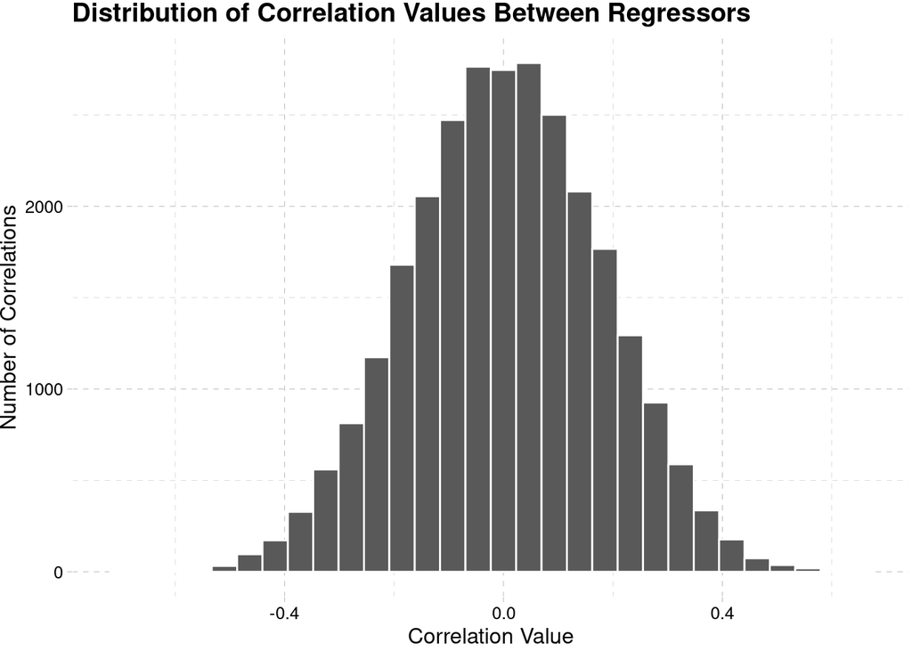

```r
corX <- cor(X)
distCor <- as_vector(corX[lower.tri(corX, diag = F)])
distTibble <- as_tibble(data.frame(R=distCor))

ggplot(distTibble, aes(x=R)) +
  geom_histogram(col="white") +
  theme_pander() +
  ylab("Number of Correlations") +
  xlab("Correlation Value") +
  ggtitle("Distribution of Correlation Values Between Regressors")
```

And now, let’s visualize the historgram of the dependent variable we are trying to predict:

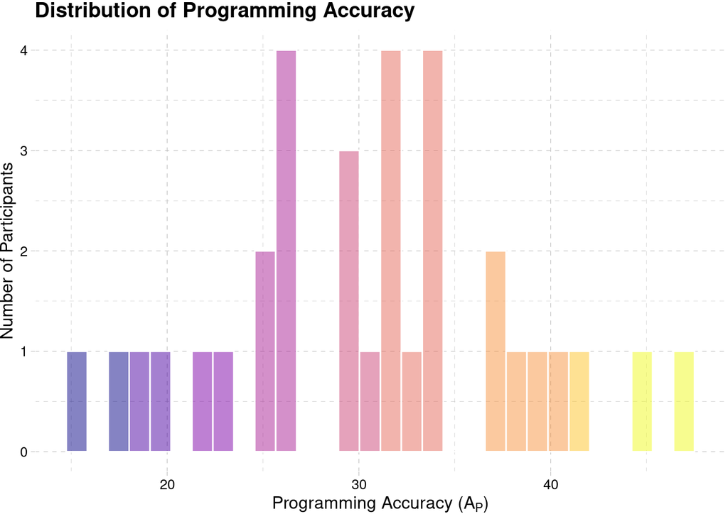

```r
dependent <- as_tibble(data.frame(ProgrammingAccuracy = Y))
#d3 <- pal_d3()
#kol = d3(7)

ggplot(dependent, aes(x=ProgrammingAccuracy, fill=cut(ProgrammingAccuracy, 10))) +
  geom_histogram(col="white", alpha=0.5, bins=30) +
  scale_fill_viridis(option = "plasma", discrete=T) +
  geom_vline(xintercept = mean(dependent$alpha)) +
  xlab(expression(paste("Programming Accuracy (", A[P], ")")))+
  ylab("Number of Participants") +
  ggtitle("Distribution of Programming Accuracy") +
  theme_pander() +
  theme(legend.position = "none")
```

# Machine-Learning with Lasso

To analyzie the data, we will use Lasso, a statitical learning system based on penalyzed regression.

## Defining the model

```r
fit <- glmnet(y = Y,
              x = X,
              alpha=1,
              standardize = T
)

fit.cv <- cv.glmnet(y = Y,
                    x = X,
                    alpha=1,
                    standardize=T,
                    nfolds=length(Y)
)
```

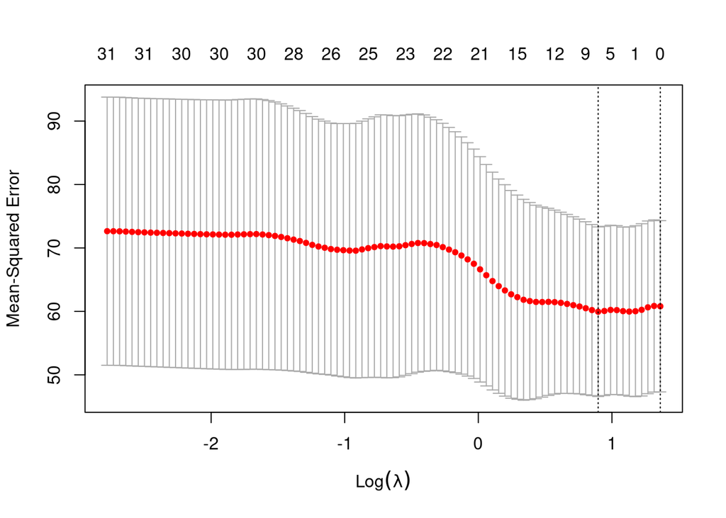

```r
plot(fit.cv)
```

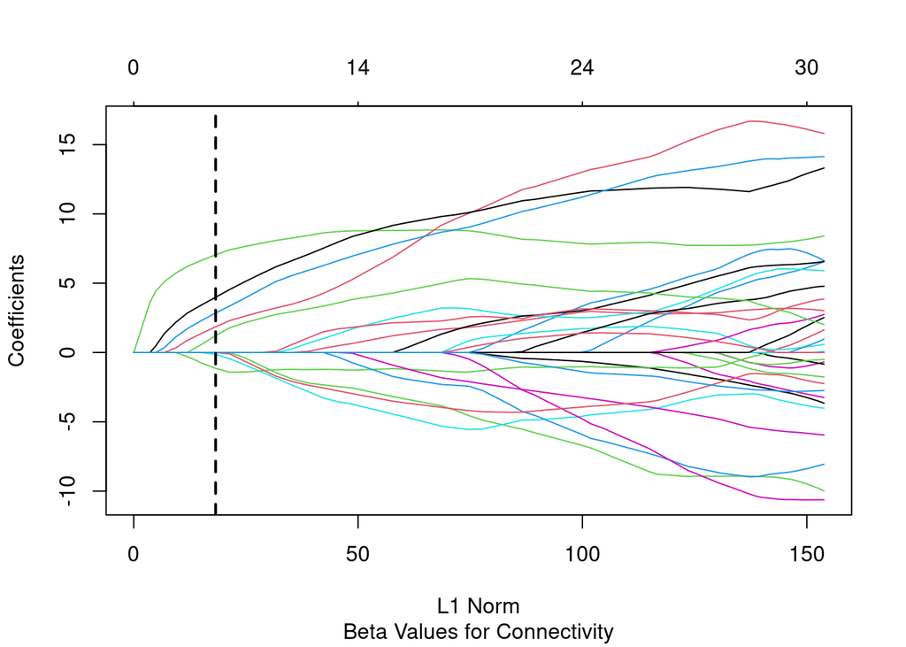

```r
plot(fit, sub="Beta Values for Connectivity")

L1norm <- sum(abs(fit$beta[,which(fit$lambda==fit.cv$lambda.min)]))
abline(v=L1norm, lwd=2, lty=2)
```

And now, plot prettier version

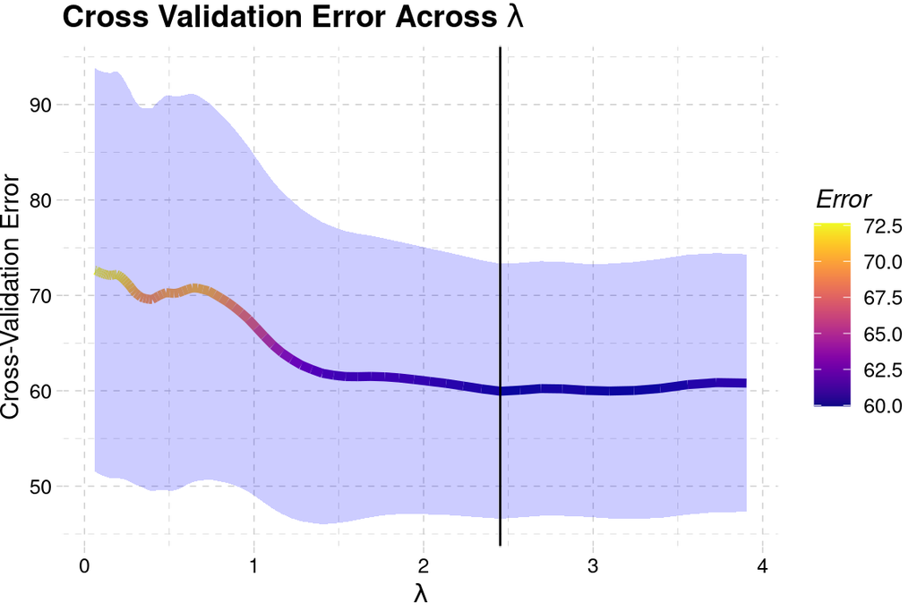

```r
lasso_df <- as_tibble(data.frame(lambda=fit.cv$lambda,
                                 error=fit.cv$cvm,
                                 sd=fit.cv$cvsd))

ggplot(lasso_df, aes(x=lambda, y=error)) +
  geom_line(aes(col=error), lwd=2) +
  scale_color_viridis("Error", option = "plasma") +
  geom_ribbon(aes(ymin=error -sd, ymax=error + sd), alpha=0.2,fill="blue") +
  xlab(expression(lambda)) +
  ylab("Cross-Validation Error") +
  ggtitle(expression(paste(bold("Cross Validation Error Across "), lambda))) +
  geom_vline(xintercept = lasso_df$lambda[lasso_df$error==min(lasso_df$error)]) +
  theme_pander() +
  theme(legend.position="right")
```

## Examining the Predictive Connectome

Let’s have a better look at the relevant connections.

```r
betas <- fit$beta[, which(fit$lambda==fit.cv$lambda.min)]
conn_betas <- as_tibble(data.frame(index=I$index, Beta=betas))
connectome <- order %>%
   filter(index %in% I$index) %>%
   inner_join(conn_betas) %>%
  dplyr::select(-censor2) %>%
   filter(Beta != 0) %>%
  arrange(index)
write_csv(connectome, file="chantel.csv")
save(fit, fit.cv, X, Y, order, I, G, file="chantel.RData")
```

Finally, we can visualize the table of connections

```r
connectome %>%
  xtable() %>%
  kable(digits = 5) %>%
  kable_styling(bootstrap_options = c("striped", "hover"))
```

| index | network | network_names | connection | censor | Beta |
| --- | --- | --- | --- | --- | --- |
| 8736 | 1-1 | Sensory/somatomotor Hand-Sensory/somatomotor Hand | 24-34 | TRUE | 7.04957 |
| 23837 | 5-5 | Default mode-Default mode | 77-91 | TRUE | 1.85360 |
| 24566 | 1-5 | Sensory/somatomotor Hand-Default mode | 14-94 | TRUE | -1.14454 |
| 42128 | 7-7 | Visual-Visual | 152-160 | TRUE | 2.85500 |
| 42861 | 5-7 | Default mode-Visual | 93-163 | TRUE | 3.98690 |
| 53782 | 8-9 | Fronto-parietal Task Control-Salience | 190-204 | TRUE | 1.22061 |
| 55525 | -1-9 | Uncertain-Salience | 85-211 | TRUE | -0.13833 |

And we can do some statistics. For example, which networks do these regions and connections belong to? Are they different from what would be expected from a random sample of connections from the connectome?

```r
region_from <- function(s) {as.numeric(strsplit(s, "-")[[1]][1])}
region_to <- function(s) {as.numeric(strsplit(s, "-")[[1]][2])}

vregion_from <- Vectorize(region_from)
vregion_to <- Vectorize(region_to)

lROIs <- unique(c(vregion_from(connectome$connection),
                  vregion_to(connectome$connection)))

rois <- power2011[lROIs,]
roi_stats <- rois %>%
  group_by(NetworkName, Color) %>%
  summarise(N=length(Color)/length(lROIs)) %>%
  add_column(Source="Lasso")
subsetPower <- filter(power2011,
                      NetworkName %in% NOI)

noi_stats <- subsetPower %>%
  group_by(NetworkName, Color) %>%
  summarise(N=length(Color)/dim(subsetPower)[1]) %>%
  add_column(Source="Power")
```

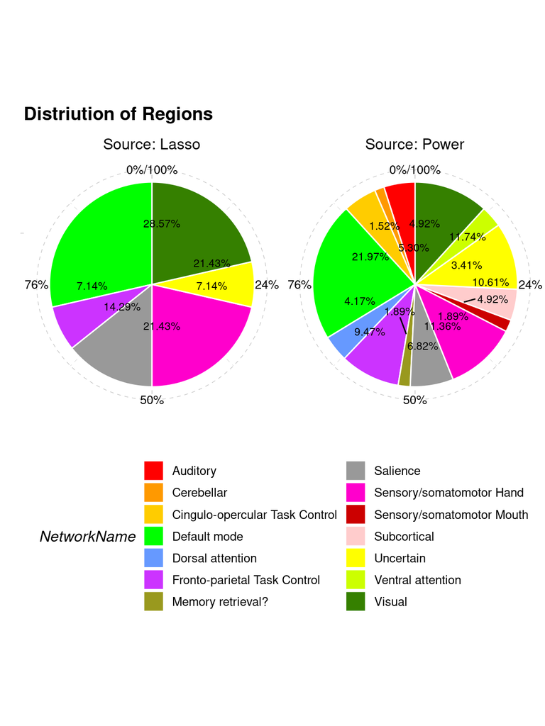

```r
total_stats <- rbind(roi_stats, noi_stats)

ggplot(total_stats, aes(x="", y=N, fill=NetworkName)) +
  geom_bar(stat = "identity", col="white", width=1) +
  facet_grid(~Source, labeller = label_both) +
  coord_polar("y", start=0) +
  scale_y_continuous(labels = scales::percent_format(accuracy = 2L)) +
  scale_fill_ucscgb() +
  ylab("") +
  xlab("") +
  ggtitle("Distriution of Regions") +
  geom_text_repel(aes(label=percent(N, .01)), col="black",
            position=position_stack(vjust=1), size=3)+
  theme_pander() +
  guides(fill=guide_legend(ncol=2)) +
  theme(legend.position = "bottom")
```

There is no difference in the distribution of ROIs:

```r
chisq.test(roi_stats$N*length(lROIs), p=roi_stats$N)
```

```
##
##  Chi-squared test for given probabilities
##
## data:  roi_stats$N * length(lROIs)
## X-squared = 0, df = 5, p-value = 1
```

And now, let’s look at the sparsity

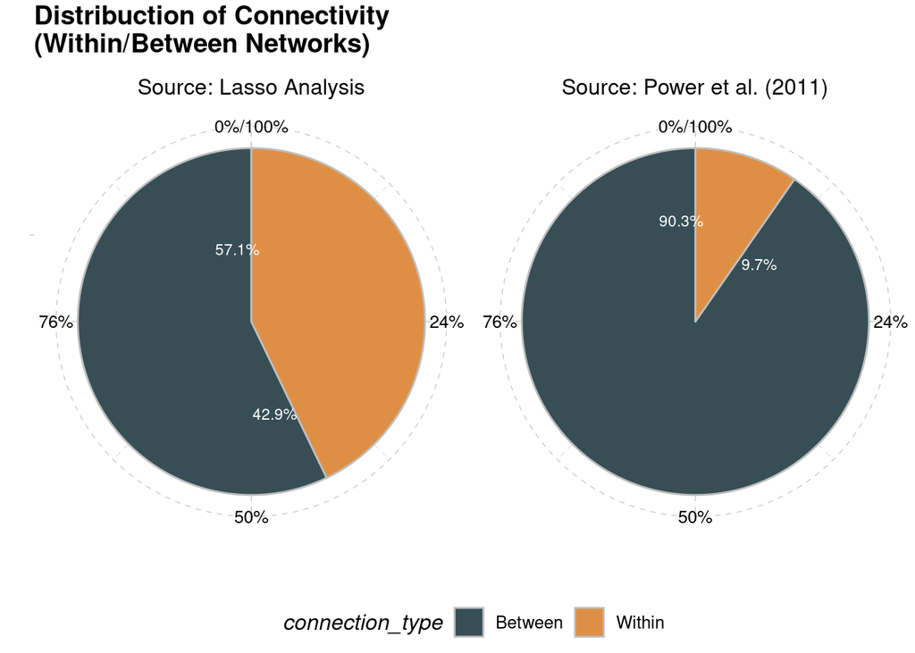

```r
net_from <- function(s) {as.character(strsplit(s, "-")[[1]][1])}
net_to <- function(s) {as.character(strsplit(s, "-")[[1]][2])}

vnet_from <- Vectorize(net_from)
vnet_to <- Vectorize(net_to)

connectivity <- function(s) {
  if (net_from(s) == net_to(s)) {
    "Within"
  } else {
    "Between"
  }
}

vconnectivity <- Vectorize(connectivity)

coi <- order %>%
  filter(censor == TRUE) %>%
  filter(network_names %in% COI)

coi$from <- vnet_from(coi$network_names)
coi$to <- vnet_to(coi$network_names)
coi$connection_type <- vconnectivity(coi$network_names)

coi_stats <- coi %>%
  group_by(connection_type) %>%
  summarise(N=length(index), P=length(index)/dim(coi)[1]) %>%
  add_column(Source = "Power et al. (2011)")


connectome$connection_type <- vconnectivity(connectome$network_names)
connectome_stats <- connectome %>%
  group_by(connection_type) %>%
  summarise(N=length(index), P=length(index)/dim(connectome)[1]) %>%
  add_column(Source = "Lasso Analysis")


total_stats2 <- rbind(connectome_stats, coi_stats)

ggplot(total_stats2, aes(x="", y=P, fill=connection_type)) +
  geom_bar(stat = "identity", col="grey", width=1) +
  facet_grid(~Source, labeller = label_both) +
  coord_polar("y", start=0) +
  scale_y_continuous(labels = scales::percent_format(accuracy = 2L)) +
  scale_fill_jama() +
  scale_color_jama() +
  ylab("") +
  xlab("") +
  ggtitle("Distribuction of Connectivity\n(Within/Between Networks)") +
  geom_text_repel(aes(label=percent(P, .1)), col="white",
            position=position_stack(vjust=1), size=3)+
  theme_pander() +
  theme(legend.position = "bottom")
```

The difference in distribution is

```r
chisq.test(connectome_stats$N, p=coi_stats$P)
```

```
##
##  Chi-squared test for given probabilities
##
## data:  connectome_stats$N
## X-squared = 8.8265, df = 1, p-value = 0.002969
```

## Visualizing the data

Here are the connections in the brain:

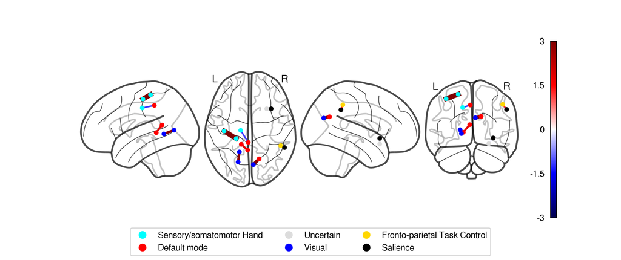

Connectivity

And here is their relative network importance, visualized as a relative size:

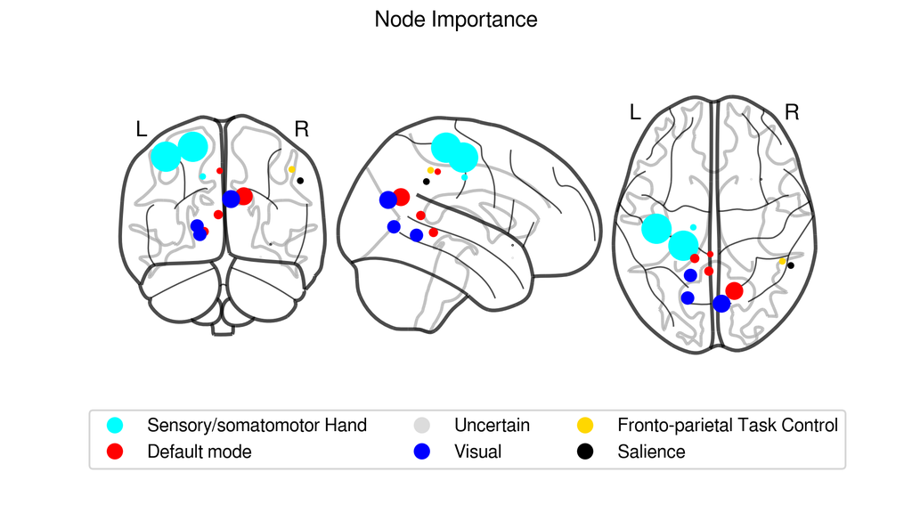

Importance

## Cross-Validated Predictions

```r
dfX <- data.frame(cbind(Y, X[,betas != 0]))
numP <- ncol(X[, betas != 0])
numO <- length(Y)
names(dfX) <- c("Y", paste("X", 1:numP, sep=""))

Yp <- rep(0, numO)  # Vector of zeros the size of Y
Xe <- matrix(rep(0, numP * numO),
             ncol = numP)  # Matrix of zeros the dimensions of X

for (i in seq(1, length(Y))) {
  subdfX <- dfX[-i,]
  lmod<-lm(Y ~ . + 1, as.data.frame(subdfX))

  yp <- predict(object=lmod,
                newdata=dfX[i, 2:(numP + 1)])
  Yp[i] <- yp
  Xe[i,] <- lmod$coefficients[2:(numP + 1)]
}
```

Now, let’s do a real predicted vs. observed graph:

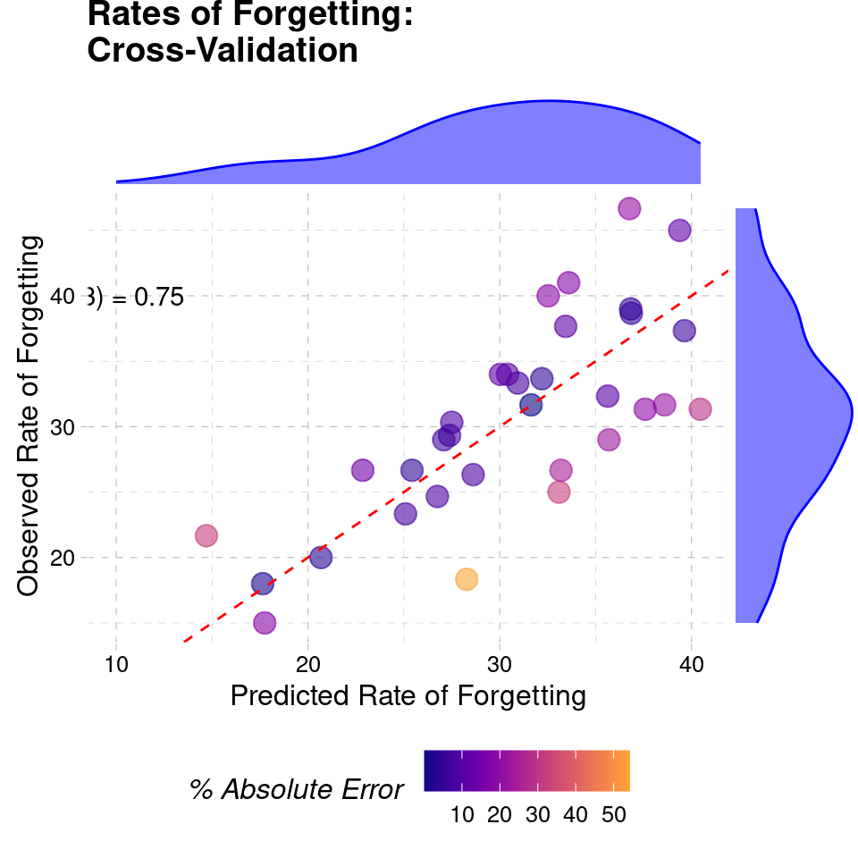

```r
wcomparison <- tibble(Observed = Y,
                     Predicted = Yp)

p <- ggplot(wcomparison, aes(x=Predicted, y=Observed,
                             col=(abs(100*(Predicted-Observed)/Observed)))) +
  geom_point(size=4, alpha=0.6) +
  geom_abline(intercept = 0, slope = 1,
              col="red",
              linetype="dashed") +
  scale_color_viridis("% Absolute Error ", option="plasma", end=0.8) +
  theme_pander() +

  theme(legend.position = "right") +
  annotate("text", x=10, y=40,
           label=paste("r(33) =",
                       floor(100*cor(Y, Yp))/100)) +
  ylab("Observed Rate of Forgetting") +
  xlab("Predicted Rate of Forgetting") +
  ggtitle("Rates of Forgetting:\nCross-Validation") +
  theme(legend.position = "bottom")

ggMarginal(p,
           fill="blue", alpha=0.5,
           type="density", #bins=13,
           col="blue",
           margins = "both")
```

## Stability of Estimated Beta Weights

And now, let’s visualize the beta weights of the connections

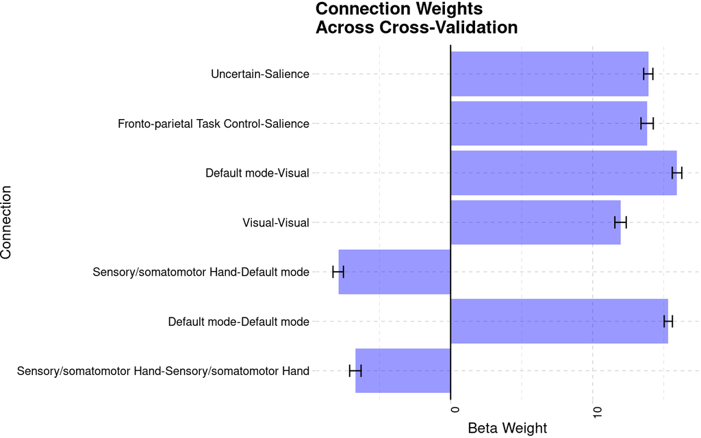

```r
colnames(Xe) <- paste("Connection", 1:nrow(connectome), paste="")
wconnections <- as_tibble(Xe)
lconnections <- pivot_longer(wconnections, cols=colnames(Xe),
                             names_to="Connection", values_to = "Beta")

ggplot(lconnections, aes(x = Connection, y = Beta)) +
  stat_summary(fun.data = "mean_sdl", geom="col", fill="blue", alpha=0.4) +
  stat_summary(fun.data = "mean_cl_boot", geom="errorbar", width=0.25) +
  scale_x_discrete(labels = connectome$network_names) +
  ggtitle("Connection Weights\nAcross Cross-Validation") +
  ylab("Beta Weight") +
  geom_hline(yintercept = 0) +
  theme_pander() +
  theme(axis.text.x = element_text(angle=90, hjust=1)) +
  coord_flip()
```

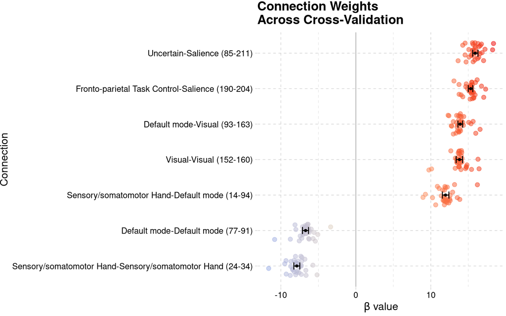

```r
ggplot(lconnections, aes(x = reorder(Connection, Beta), y = Beta)) +
  geom_point(aes(col=Beta), alpha=.5,
             size=2,
             position = position_jitter(height = 0, width = 0.3)) +
  stat_summary(fun.data = "mean_sdl", geom="point", fill="black", alpha=1, size=1) +
  scale_color_gradient2(low = "dodgerblue",
                        mid = "wheat",
                        high = "red2",
                        midpoint = 0) +
  scale_x_discrete(labels =
                     paste(connectome$network_names,
                           " (",
                           connectome$connection,
                           ")", sep="")) +
  ggtitle("Connection Weights\nAcross Cross-Validation") +
  ylab(expression(paste(beta, " value"))) +
  xlab("Connection") +
  geom_hline(yintercept = 0, col="grey") +
  stat_summary(fun.data = "mean_cl_boot",
               col="black", geom="errorbar", width=0.2) +
  #scale_color_viridis(option="plasma", begin=0.2, end=0.9) +

  theme_pander() +
  theme(axis.text.y = element_text(angle=0, hjust=1),
        legend.position = "NA") +
  #ylim(-0.05, 0.1) +
  coord_flip()
```

# Testing the validity of the Lasso model

To test the validity, we remove all the connections with significant beta values, and check whether the results are still significant.

```r
XX <- X[, conn_betas$Beta == 0]

fit_wo <- glmnet(y = Y,
                 x = XX,
                 alpha=1,
                 lambda = fit$lambda,
                 standardize = T
)

fit_wo.cv <- cv.glmnet(y = Y,
                       x = XX,
                       alpha=1,
                       lambda = fit$lambda,
                       standardize=T,
                       nfolds=length(Y)
)
```

It is easy to see that the model does not converge; at value of $\lambda_{min}$, all beta weights are zero.

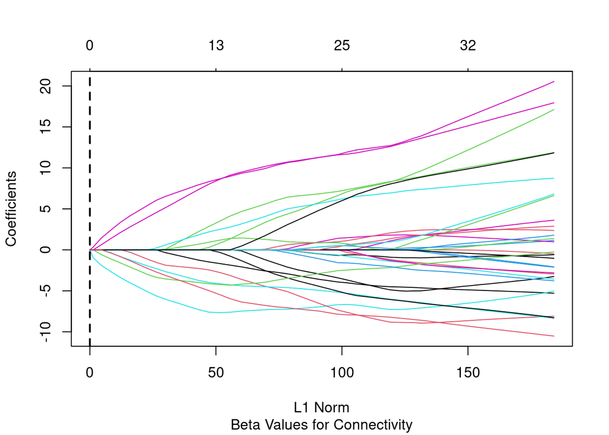

```r
#plot(fit.cv)
plot(fit_wo, sub="Beta Values for Connectivity")
L1norm <- sum(abs(fit_wo$beta[,which(fit_wo$lambda==fit_wo.cv$lambda.min)]))
abline(v=L1norm, lwd=2, lty=2)
```

And now, we can plot the $\lambda$-curve:

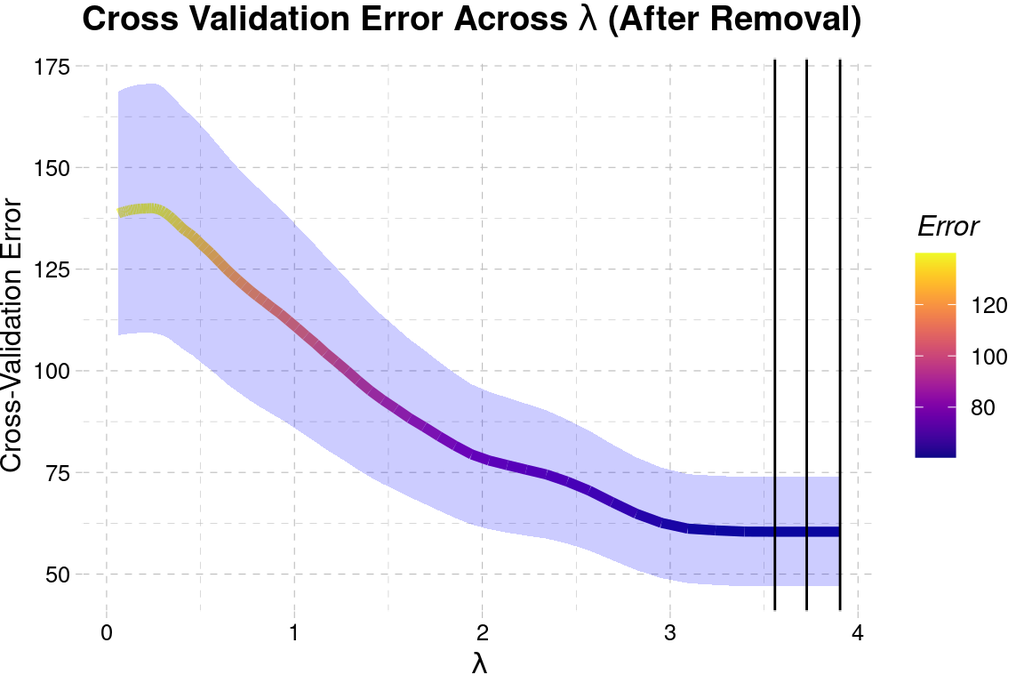

```r
lasso_df_wo <- tibble(lambda=fit_wo.cv$lambda,
                   error=fit_wo.cv$cvm,
                   sd=fit_wo.cv$cvsd)

ggplot(lasso_df_wo, aes(x = lambda, y = error)) +
  geom_line(aes(col=error), lwd=2) +
  scale_color_viridis("Error", option = "plasma") +
  geom_ribbon(aes(ymin = error - sd,
                  ymax = error + sd),
              alpha = 0.2,
              fill="blue") +
  xlab(expression(lambda)) +
  ylab("Cross-Validation Error") +
  ggtitle(expression(paste(bold("Cross Validation Error Across "), lambda, bold(" (After Removal)")))) +
  geom_vline(xintercept = lasso_df_wo$lambda[lasso_df_wo$error==min(lasso_df_wo$error)]) +
  theme_pander() +
  theme(legend.position="right")
```

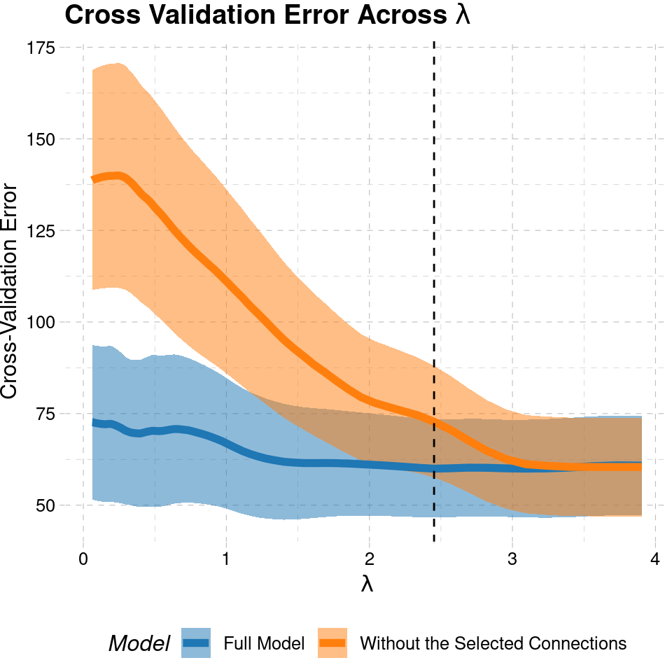

```r
lasso_df$Model <- "Full Model"
lasso_df_wo$Model <- "Without the Selected Connections"

lasso_uber <- rbind(lasso_df, lasso_df_wo)

ggplot(lasso_uber, aes(x = lambda, y = error, fill=Model)) +
  scale_color_d3() +
  scale_fill_d3()+
  geom_ribbon(aes(ymin = error - sd,
                  ymax = error + sd),
              alpha = 0.5,
              #fill="blue"
              ) +
  geom_line(aes(col=Model), lwd=2) +
  xlab(expression(lambda)) +
  ylab("Cross-Validation Error") +
  ggtitle(expression(paste(bold("Cross Validation Error Across "), lambda))) +
  geom_vline(xintercept = lasso_df$lambda[lasso_df$error==min(lasso_df$error)],
             linetype="dashed") +
  theme_pander() +
  theme(legend.position="bottom")
```

## Variance Inflation Factor

Then, we examine the Variance Inflation Factor (VIF). To calculate the VIF, we need to first create a linear model of the factor effects:

```r
dfX <- data.frame(cbind(Y, X[,betas != 0]))
mod<-lm(Y ~ . + 1, as.data.frame(dfX))
```

We can now calculate the VIF and turn the results into a tibble:

```r
vif(mod)
```

```
##       V2       V3       V4       V5       V6       V7       V8
## 1.486805 1.172687 1.455605 1.185358 1.067509 1.177142 1.091421
```

```r
vifs <- vif(mod)
vifsT <- tibble(VIF=vifs)
```

And, finally, we can plot an histogram of the distribution of VIF values.

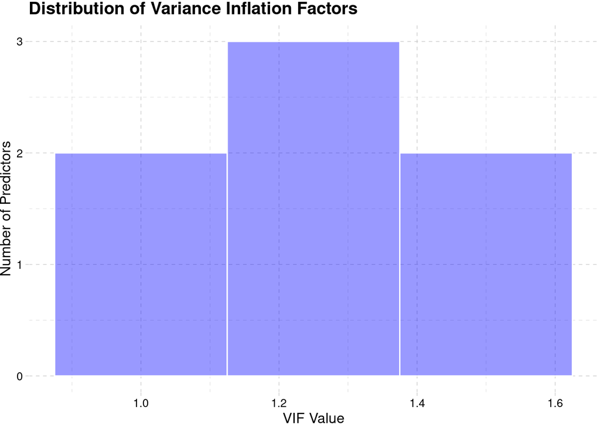

```r
ggplot(vifsT, aes(x=VIF)) +
  geom_histogram(col="white", binwidth = 0.25, fill="blue", alpha=0.4) +
  theme_pander() +
  xlab("VIF Value") +
  ylab("Number of Predictors") +
  ggtitle("Distribution of Variance Inflation Factors")
```

```r
rois <- c(vregion_from(connectome$connection), vregion_to(connectome$connection))
rois_t <- tibble(roi = rois)
rois_t %>%
  group_by(roi) %>%
  summarize(N = length(roi)) %>%
  xtable() %>%
  kable(digits = 5) %>%
  kable_styling(bootstrap_options = c("striped", "hover"))
```

| roi | N |
| --- | --- |
| 14 | 1 |
| 24 | 1 |
| 34 | 1 |
| 77 | 1 |
| 85 | 1 |
| 91 | 1 |
| 93 | 1 |
| 94 | 1 |
| 152 | 1 |
| 160 | 1 |
| 163 | 1 |
| 190 | 1 |
| 204 | 1 |
| 211 | 1 |